# Machine Learning: Clustering

Evan Carey, created for BH Analytics

# Objectives

- Understand how clustering differs from supervised learning approaches
- Overview of different algorithms (kmeans and hierarchical clustering)
- Scaling data
- Summarizing resulting clusters
- Identifying the optimal number of clusters

# Import and examine wholesale data.

We’ll use the `wholesale` dataset which you can find in your data folder. First, bring in the data and examine it.

```r
# import dataset
library(readr)
wholesale <-
  read_csv('Data/wholesale_customers.csv')
head(wholesale)
```

```
## # A tibble: 6 x 8
##   Channel Region Fresh  Milk Grocery Frozen Detergents_Paper Delicassen
##     <dbl>  <dbl> <dbl> <dbl>   <dbl>  <dbl>            <dbl>      <dbl>
## 1       2      3 12669  9656    7561    214             2674       1338
## 2       2      3  7057  9810    9568   1762             3293       1776
## 3       2      3  6353  8808    7684   2405             3516       7844
## 4       1      3 13265  1196    4221   6404              507       1788
## 5       2      3 22615  5410    7198   3915             1777       5185
## 6       2      3  9413  8259    5126    666             1795       1451
```

This data represents buying patterns of clients of a wholesale distributor. The attributes are:

1. FRESH: annual spending (m.u.) on fresh products (Continuous)
2. MILK: annual spending (m.u.) on milk products (Continuous)
3. GROCERY: annual spending (m.u.)on grocery products (Continuous)
4. FROZEN: annual spending (m.u.)on frozen products (Continuous)
5. DETERGENTS_PAPER: annual spending (m.u.) on detergents and paper products (Continuous)
6. DELICATESSEN: annual spending (m.u.)on and delicatessen products (Continuous)
7. CHANNEL: customers’ Channel - Horeca (Hotel/Restaurant/Cafe:) or Retail channel (Nominal)
8. REGION: customers’ Region: Lisbon, Oporto or Other (Nominal)

```r
# fix column names
# Fix the column name
colnames(wholesale) <-
  c('Channel', 'Region', 'Fresh', 'Milk',
    'Grocery', 'Frozen','Detergents_Paper', 'Delicatessen')
```

```r
# Describe dataset
library(Hmisc)
describe(wholesale)
```

```
## wholesale
##
##  8  Variables      440  Observations
## -----------------------------------------------------------------------------------------------------------------------------------------------------
## Channel
##        n  missing distinct     Info     Mean      Gmd
##      440        0        2    0.656    1.323   0.4381
##
## Value          1     2
## Frequency    298   142
## Proportion 0.677 0.323
## -----------------------------------------------------------------------------------------------------------------------------------------------------
## Region
##        n  missing distinct     Info     Mean      Gmd
##      440        0        3    0.623    2.543   0.6951
##
## Value          1     2     3
## Frequency     77    47   316
## Proportion 0.175 0.107 0.718
## -----------------------------------------------------------------------------------------------------------------------------------------------------
## Fresh
##        n  missing distinct     Info     Mean      Gmd      .05      .10      .25      .50      .75      .90      .95
##      440        0      433        1    12000    12256    401.9    915.6   3127.8   8504.0  16933.8  27090.5  36818.5
##
## lowest :      3      9     18     23     37, highest:  56083  56159  68951  76237 112151
## -----------------------------------------------------------------------------------------------------------------------------------------------------
## Milk
##        n  missing distinct     Info     Mean      Gmd      .05      .10      .25      .50      .75      .90      .95
##      440        0      421        1     5796     6152    593.8    889.8   1533.0   3627.0   7190.2  12229.9  16843.4
##
## lowest :    55   112   134   201   254, highest: 38369 43950 46197 54259 73498
## -----------------------------------------------------------------------------------------------------------------------------------------------------
## Grocery
##        n  missing distinct     Info     Mean      Gmd      .05      .10      .25      .50      .75      .90      .95
##      440        0      430        1     7951     8365    851.5   1381.9   2153.0   4755.5  10655.8  18910.1  24033.5
##
## lowest :     3   137   218   223   245, highest: 45828 55571 59598 67298 92780
## -----------------------------------------------------------------------------------------------------------------------------------------------------
## Frozen
##        n  missing distinct     Info     Mean      Gmd      .05      .10      .25      .50      .75      .90      .95
##      440        0      426        1     3072     3635    136.8    281.3    742.2   1526.0   3554.2   7545.3   9930.7
##
## lowest :    25    33    36    38    42, highest: 18028 18711 35009 36534 60869
## -----------------------------------------------------------------------------------------------------------------------------------------------------
## Detergents_Paper
##        n  missing distinct     Info     Mean      Gmd      .05      .10      .25      .50      .75      .90      .95
##      440        0      417        1     2881     3927     63.7     99.6    256.8    816.5   3922.0   7438.3  12043.2
##
## lowest :     3     5     7     9    10, highest: 24171 24231 26701 38102 40827
## -----------------------------------------------------------------------------------------------------------------------------------------------------
## Delicatessen
##        n  missing distinct     Info     Mean      Gmd      .05      .10      .25      .50      .75      .90      .95
##      440        0      403        1     1525     1677    63.95   180.80   408.25   965.50  1820.25  2945.90  4485.40
##
## lowest :     3     7     8    11    18, highest:  8550 14351 14472 16523 47943
##
## Value          0   500  1000  1500  2000  2500  3000  3500  4000  4500  5000  5500  6000  6500  7000  8000  8500 14500 16500 48000
## Frequency     65   121    82    54    42    23    18     8     1     5     8     1     3     2     1     1     1     2     1     1
## Proportion 0.148 0.275 0.186 0.123 0.095 0.052 0.041 0.018 0.002 0.011 0.018 0.002 0.007 0.005 0.002 0.002 0.002 0.005 0.002 0.002
##
## For the frequency table, variable is rounded to the nearest 500
## -----------------------------------------------------------------------------------------------------------------------------------------------------
```

# K-means clustering

K-means clustering (sometimes called ‘Lloyd’s algorithm’) works by attempting to group data into k disjoint groups of equal variance.

- The means of the clusters are called *centroids*
- The algorithm seeks to choose centroids that minimize *inertia*, or a within-cluster sum-of-squares criterion.
- Makes the assumptions that clusters are *convex* (not open) and *isotropic* (globular, uniform in all directions)
- Lower values of inertia are better, although it is not a normalized metric.
- “K-means will always converge, however this may be to a local minimum. This is highly dependent on the initialization of the centroids.”
- K-means generally performs well (quickly), converges, and is good with known numbers of clusters
- On the downside, it may force clusters that don’t apply to the data.

Let’s create a smaller dataset with only the columns of interest for clustering.

```r
# create subset
library(dplyr)
wholesale_sub <-
  wholesale %>%
  select("Fresh":"Delicatessen")
```

Implementation is simple: use the `kmeans` function with `centers` parameter.

Notice we had to pre-specify the number of clusters (we picked 3 here).

```r
# implement k-means clustering, n_clusers = 3
res_kmeans <-
  kmeans(wholesale_sub,centers = 3)
# print the labels
res_kmeans$cluster
```

```
##   [1] 1 1 1 1 3 1 1 1 1 2 1 1 3 1 3 1 1 1 1 1 1 1 3 2 3 1 1 1 2 3 1 1 1 3 1 1 3 1 2 3 3 1 1 2 1 2 2 2 1 2 1 1 3 1 3 1 2 1 1 1 1 2 1 1 1 2 1 1 1 1 1 1
##  [73] 1 1 1 1 1 2 1 1 1 1 1 1 1 2 2 3 1 3 1 1 2 1 1 1 1 1 1 1 1 1 1 3 1 1 1 1 1 2 1 2 1 1 1 1 1 1 1 1 1 1 1 1 3 3 1 1 1 3 1 1 1 1 1 1 1 1 1 1 1 3 3 1
## [145] 1 2 1 1 1 3 1 1 1 1 1 2 1 1 1 1 1 1 1 2 1 2 1 1 1 1 1 2 1 2 1 1 3 1 1 1 1 3 1 3 1 1 1 1 1 1 1 1 1 1 1 1 3 1 1 1 2 2 3 1 1 2 1 1 1 2 1 2 1 1 1 1
## [217] 2 1 1 1 1 1 1 1 1 1 1 1 1 1 1 1 3 1 1 1 1 1 1 3 3 3 1 1 1 1 1 1 1 1 1 2 1 3 1 3 1 1 3 3 1 1 3 1 1 2 2 1 2 1 1 1 1 3 1 1 3 1 1 1 1 1 3 3 3 3 1 1
## [289] 1 3 1 1 1 1 1 1 1 1 1 1 1 2 1 1 2 1 2 1 1 2 1 3 2 1 1 1 1 1 1 2 1 1 1 1 3 3 1 1 1 1 1 2 1 2 1 3 1 1 1 1 1 1 1 2 1 1 1 3 1 2 1 2 1 2 1 1 1 1 1 1
## [361] 1 1 1 1 1 1 1 1 1 1 3 1 1 1 1 1 1 3 1 1 3 1 3 1 2 1 1 1 1 1 1 1 1 3 1 1 1 1 1 1 1 3 3 3 1 1 3 2 1 1 1 1 1 1 1 1 1 1 2 1 1 1 3 1 1 1 1 3 1 1 1 1
## [433] 1 1 1 3 3 2 1 1
```

Let’s add these labels as a column to the original data.

```r
# Add as new column
wholesale['klbl'] <-
  factor(res_kmeans$cluster)
```

Let’s visualize the data according to our new clusters. We are choosing to plot them across some pairs of variables chosen at random: `Fresh` and `Frozen`, and `Fresh` and `Grocery`. Does our clustering approach distinguish customers across these dimensions?

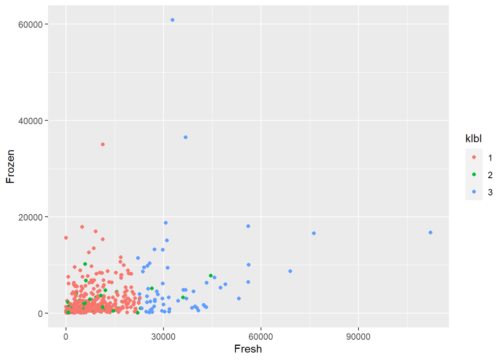

```r
# Create scatterplots
library(ggplot2)
ggplot(wholesale,
       aes(Fresh,Frozen, color = klbl)) +
  geom_point()
```

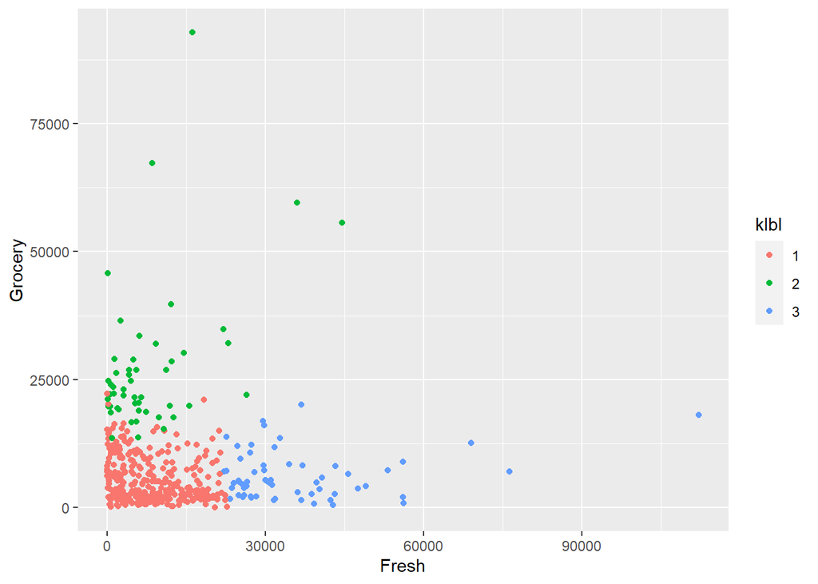

```r
# Create scatterplots
library(ggplot2)
ggplot(wholesale,
       aes(Fresh,Grocery, color = klbl)) +
  geom_point()
```

Let’s use some of the other information from the dataset, the region and channel columns. First, let’s convert them to categories and rename the categories according the attribute information that we have.

```r
# change factor labels

wholesale$Channel <-
  factor(wholesale$Channel,
         levels = c(1,2),
         labels = c('HoReCa','Retail'))
wholesale$Region <-
  factor(wholesale$Region,
         levels = c(1,2,3),
         labels = c('Lisbon','Oporto','Other'))
head(wholesale)
```

```
## # A tibble: 6 x 9
##   Channel Region Fresh  Milk Grocery Frozen Detergents_Paper Delicatessen klbl
##   <fct>   <fct>  <dbl> <dbl>   <dbl>  <dbl>            <dbl>        <dbl> <fct>
## 1 Retail  Other  12669  9656    7561    214             2674         1338 1
## 2 Retail  Other   7057  9810    9568   1762             3293         1776 1
## 3 Retail  Other   6353  8808    7684   2405             3516         7844 1
## 4 HoReCa  Other  13265  1196    4221   6404              507         1788 1
## 5 Retail  Other  22615  5410    7198   3915             1777         5185 3
## 6 Retail  Other   9413  8259    5126    666             1795         1451 1
```

If we examine our data by our clusters, we see another view of how the clustering algorithm has grouped the data.

```r
res1 <-
  wholesale %>%
  group_by(klbl) %>%
  summarise(across(Fresh:Delicatessen,sum))
res1
```

```
## # A tibble: 3 x 7
##   klbl    Fresh    Milk Grocery Frozen Detergents_Paper Delicatessen
##   <fct>   <dbl>   <dbl>   <dbl>  <dbl>            <dbl>        <dbl>
## 1 1     2723645 1262119 1742550 848978           585109       375374
## 2 2      400002  925571 1378695  99834           620368       112601
## 3 3     2156484  362667  377317 402838            62380       182968
```

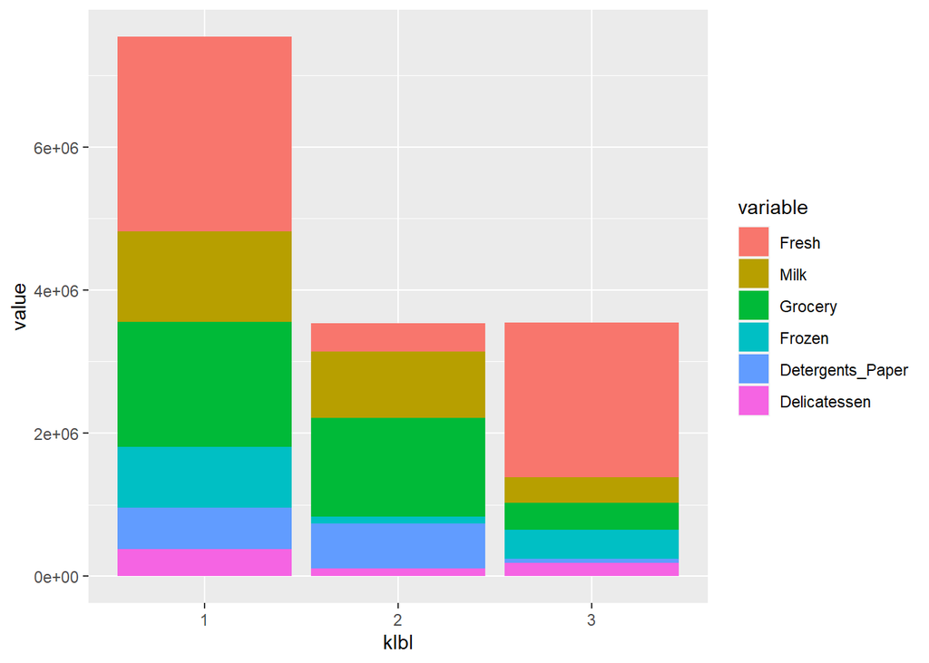

```r
# plot
library(reshape2)
ggplot(melt(res1),
       aes(x=klbl,y=value,fill=variable)) + geom_bar(stat='identity')
```

Let’s examine how the clustering has differentiated across channel.

```r
# make table of counts
table(wholesale$Channel,wholesale$klbl)
```

```
##
##            1   2   3
##   HoReCa 244   2  52
##   Retail  86  48   8
```

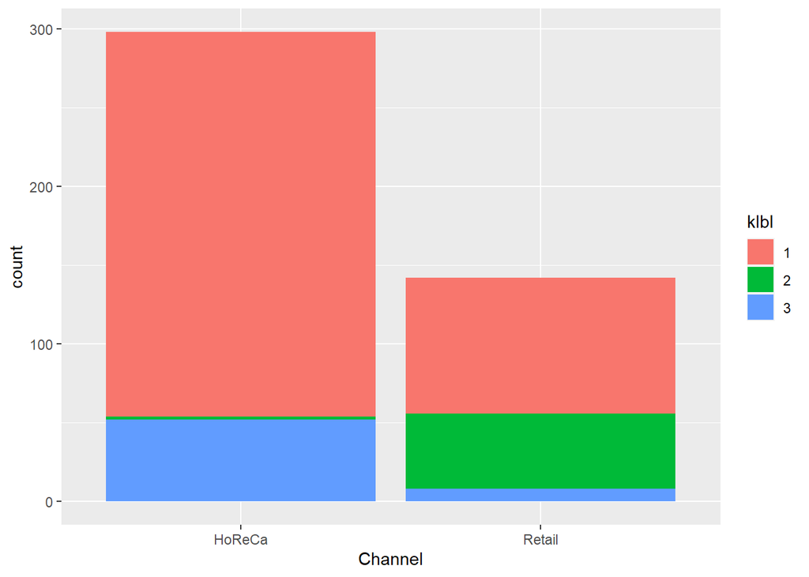

```r
# check channel by klbl plot
ggplot(wholesale, aes(x=Channel, fill=klbl)) +
  geom_bar()
```

```r
# make table of counts
table(wholesale$Region,wholesale$klbl)
```

```
##
##            1   2   3
##   Lisbon  56  10  11
##   Oporto  35   8   4
##   Other  239  32  45
```

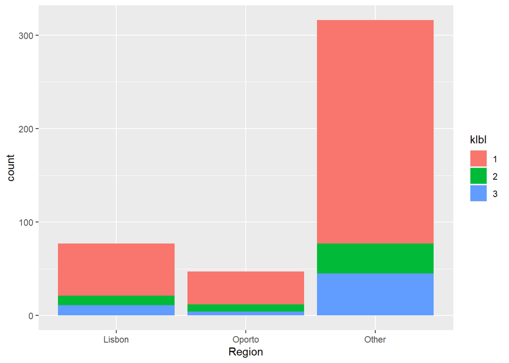

```r
# check channel by klbl plot
ggplot(wholesale, aes(x=Region, fill=klbl)) +
  geom_bar()
```

The `sklearn` documentation (from Python) prints these warnings in red with K-means and it applies here as well:

**Warning:** There is absolutely no guarantee of recovering a ground truth. First, choosing the right number of clusters is hard. Second, the algorithm is sensitive to initialization, and can fall into local minima.

> **Don’t over-interpret clustering results!**

# Exercise Cl.01

1. Reshape the mtcars data into a suitable data set for a clustering analysis.
2. Omit the `cyl` (cylinders, the second column that takes values 4, 6, or 8) column.
3. Use the `mpg` and `wt` columns. Perform K-means clustering with 3 groups and examine the results compared to the original dataset. Note this is a very small dataset.

# Weaknesses of KMeans

- Must choose number of clusters in advance
- Sensitive to starting values
- Wants regular-shaped geometry

# Agglomerative Clustering

Agglomerative clustering is *hierarchical* clustering method using a “bottom-up” approach. Hierarchical methods work by successively splitting or joining clusters (like a plant taxonomy that splits plants into family, genus, species…)

- As with KMeans, the “Ward” approach seeks to minimize a sum-of-squared distance within clusters.
- “Complete” minimizes maximum distances
- “Average” minimizes mean distances

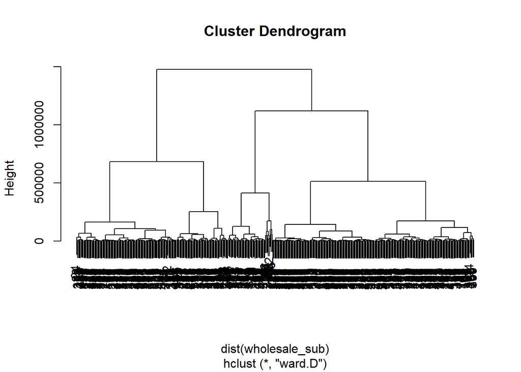

```r
## Implement hierarchical clustering
clust_res <-
  hclust(d=dist(wholesale_sub),method = 'ward.D')
plot(clust_res)
```

```r
## Make labels using 'cut tree'
ag_lbl <-
  cutree(clust_res,3)
## add variable to dataset
wholesale$aglbl <-
  factor(ag_lbl)
```

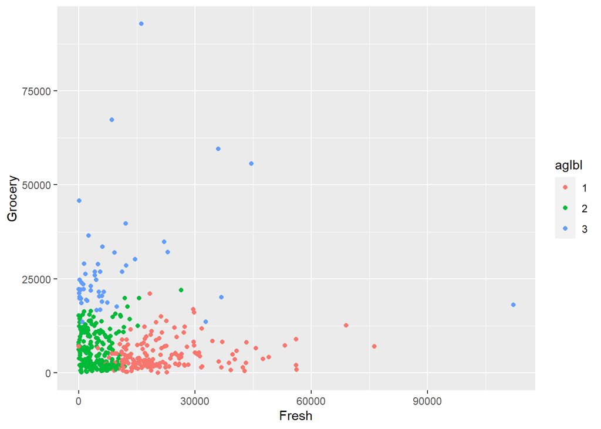

```r
# Create scatterplots
library(ggplot2)
ggplot(wholesale,
       aes(Fresh,Grocery, color = aglbl)) +
  geom_point()
```

```r
res1 <-
  wholesale %>%
  group_by(aglbl) %>%
  summarise(across(Fresh:Delicatessen,sum))
res1
```

```
## # A tibble: 3 x 7
##   aglbl   Fresh    Milk Grocery Frozen Detergents_Paper Delicatessen
##   <fct>   <dbl>   <dbl>   <dbl>  <dbl>            <dbl>        <dbl>
## 1 1     3670797  605783  814220 737955           166525       265694
## 2 2     1110467 1037510 1319531 423860           487528       259645
## 3 3      498867  907064 1364811 189835           613804       145604
```

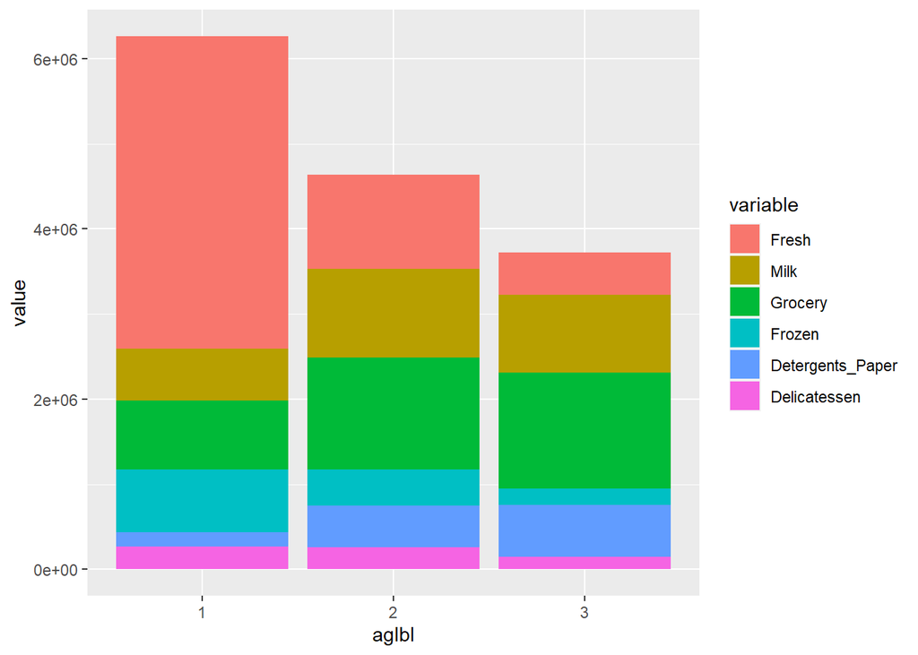

```r
# plot
library(reshape2)
ggplot(melt(res1),
       aes(x=aglbl,y=value,fill=variable)) + geom_bar(stat='identity')
```

Let’s examine how the clustering has differentiated across channel.

```r
# make table of counts
table(wholesale$Channel,wholesale$aglbl)
```

```
##
##            1   2   3
##   HoReCa 137 158   3
##   Retail  31  65  46
```

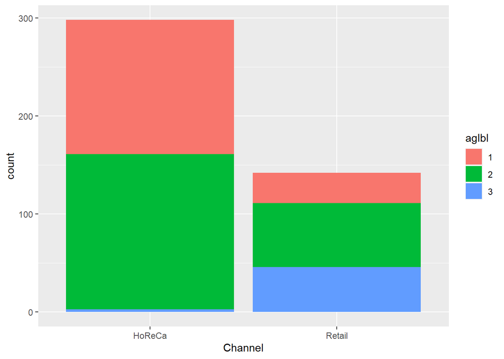

```r
# check channel by aglbl plot
ggplot(wholesale, aes(x=Channel, fill=aglbl)) +
  geom_bar()
```

Let’s examine how the clustering has differentiated across Region.

```r
# make table of counts
table(wholesale$Region,wholesale$aglbl)
```

```
##
##            1   2   3
##   Lisbon  27  42   8
##   Oporto  20  18   9
##   Other  121 163  32
```

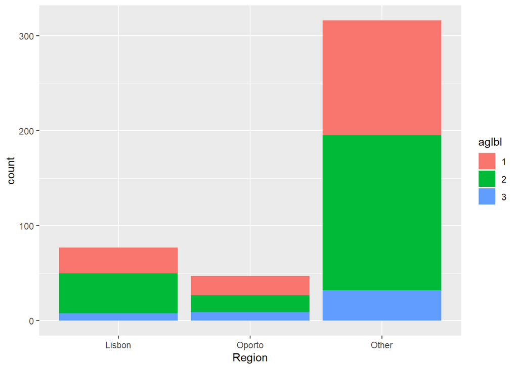

```r
# check channel by aglbl plot
ggplot(wholesale, aes(x=Region, fill=aglbl)) +
  geom_bar()
```

# Exercise Cl.02

1. Perform agglomerative clustering with 3 groups on the mtcars dataset
2. examine the results compared to the original dataset.

# Complete Clustering Method:

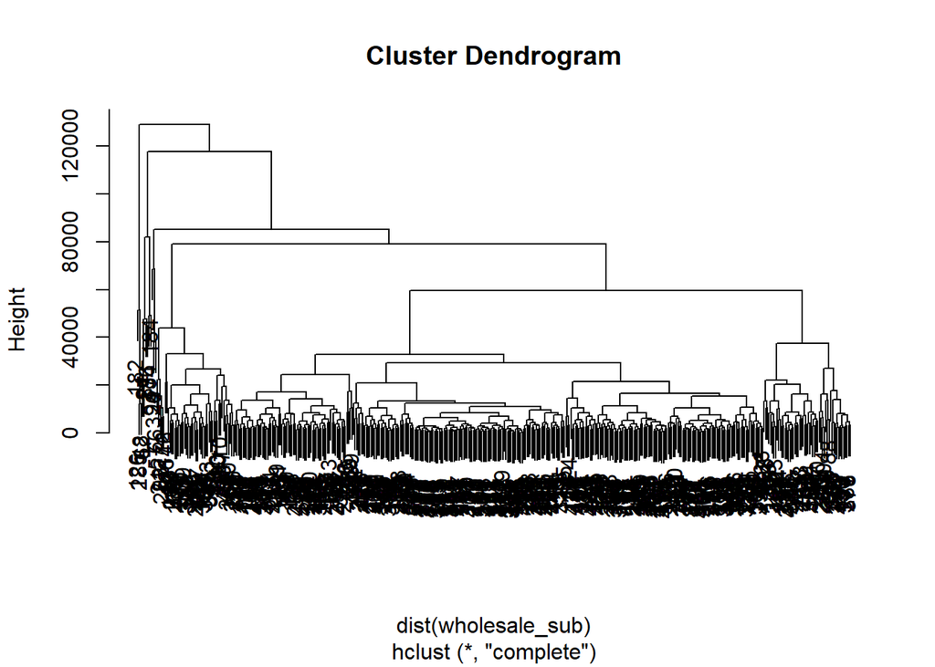

```r
## Implement hierarchical clustering
clust_res <-
  hclust(d=dist(wholesale_sub),method = 'complete')
plot(clust_res)
```

```r
## Make labels using 'cut tree'
ag_lbl2 <-
  cutree(clust_res,3)
## add variable to dataset
wholesale$aglbl2 <-
  factor(ag_lbl2)
```

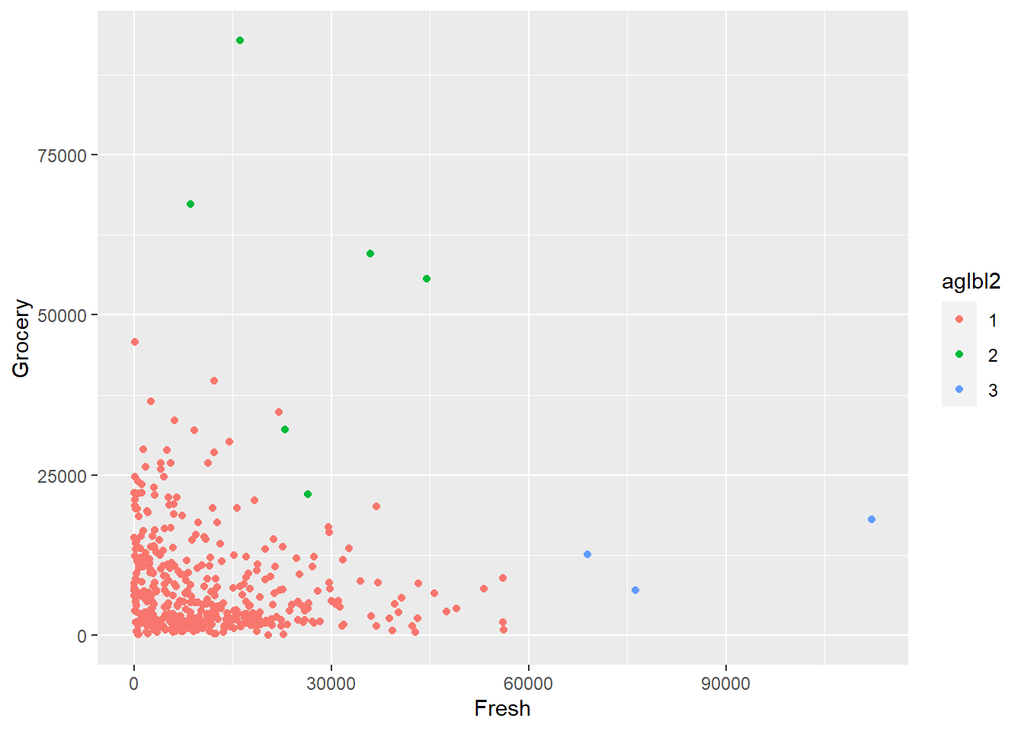

```r
# Create scatterplots
library(ggplot2)
ggplot(wholesale,
       aes(Fresh,Grocery, color = aglbl2)) +
  geom_point()
```

```r
res1 <-
  wholesale %>%
  group_by(aglbl2) %>%
  summarise(across(Fresh:Delicatessen,sum))
res1
```

```
## # A tibble: 3 x 7
##   aglbl2   Fresh    Milk Grocery  Frozen Detergents_Paper Delicatessen
##   <fct>    <dbl>   <dbl>   <dbl>   <dbl>            <dbl>        <dbl>
## 1 1      4868404 2259120 3131323 1291341          1107172       629002
## 2 2       154388  253726  329380   18334           154208        30067
## 3 3       257339   37511   37859   41975             6477        11874
```

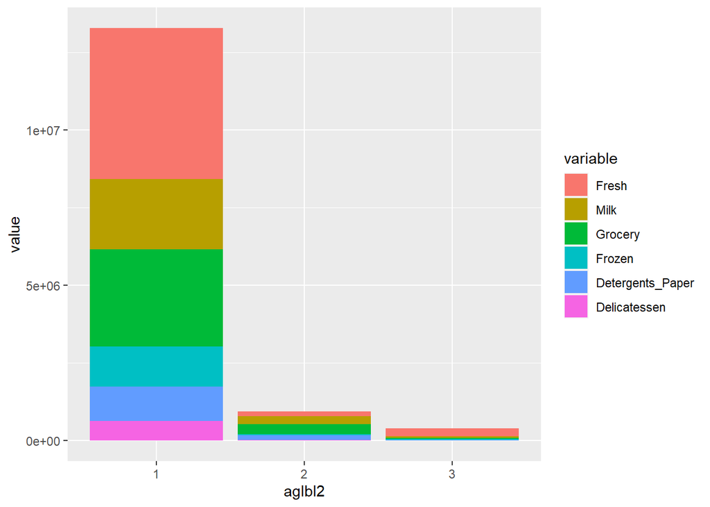

```r
# plot
library(reshape2)
ggplot(melt(res1),
       aes(x=aglbl2,y=value,fill=variable)) + geom_bar(stat='identity')
```

Let’s examine how the clustering has differentiated across channel.

```r
# make table of counts
table(wholesale$Channel,wholesale$aglbl2)
```

```
##
##            1   2   3
##   HoReCa 295   0   3
##   Retail 136   6   0
```

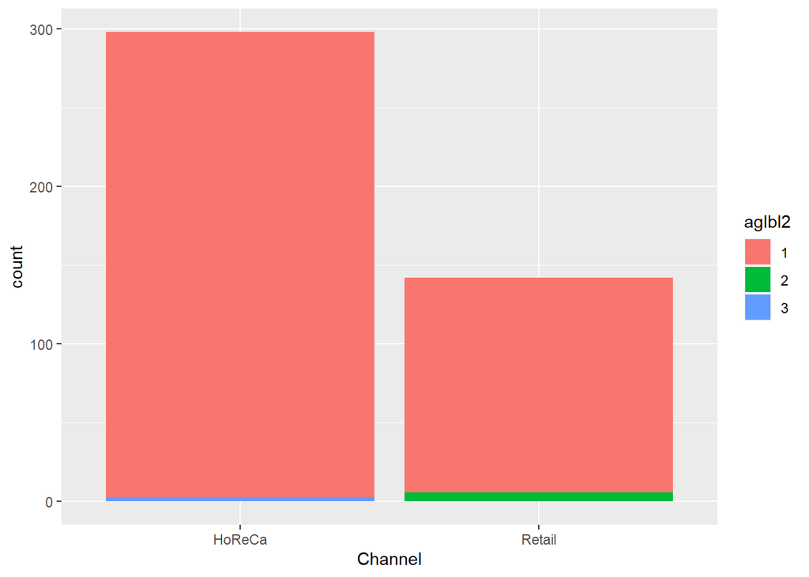

```r
# check channel by aglbl plot
ggplot(wholesale, aes(x=Channel, fill=aglbl2)) +
  geom_bar()
```

Let’s examine how the clustering has differentiated across Region.

```r
# make table of counts
table(wholesale$Region,wholesale$aglbl2)
```

```
##
##            1   2   3
##   Lisbon  77   0   0
##   Oporto  46   1   0
##   Other  308   5   3
```

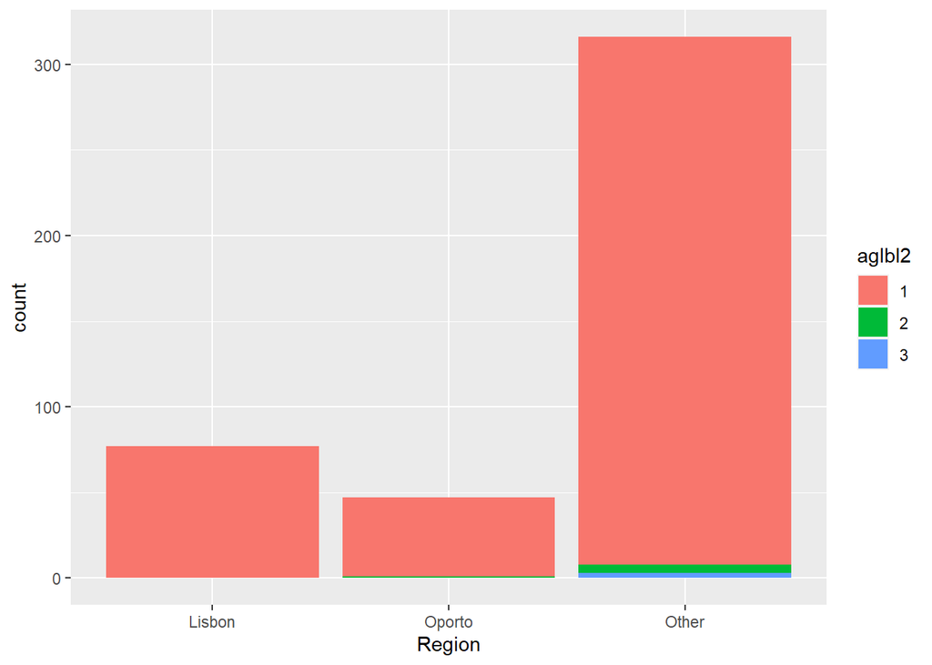

```r
# check channel by aglbl plot
ggplot(wholesale, aes(x=Region, fill=aglbl2)) +
  geom_bar()
```

# Evaluating clusters

As the Kmeans documentation mentions, choosing the number of clusters correctly is hard. Evaluating the “success” of a clustering algorithm presents challenges: there may be no ground truth to which to compare the cluster labels.

# Silhouette Coefficient

Although some measures of evaluating clusters exist where ground labels are known, this is rarely the case in an unsupervised learning context. The *silhouette coefficient* is a measure of how well a cluster is defined. The silhouette coefficient is specified as the measure of the mean distance of a point to others in its class compared to the mean distance to the next nearest class.

- From -1 for incorrect clustering and +1 for highly dense clustering.
- Scores around zero indicate overlapping clusters.
- The score is higher when clusters are dense and well separated

```r
## start with 2 clusters and calculate the width
library(cluster)
kres <- kmeans(wholesale_sub,
               centers = 2)
kmeans_sil <-
  silhouette(as.numeric(kres$cluster),
             dist = dist(wholesale_sub)^2) ## square since this is how kmeans works
# Summarize the result
summary(kmeans_sil)
```

```
## Silhouette of 440 units in 2 clusters from silhouette.default(x = as.numeric(kres$cluster), dist = dist(wholesale_sub)^2) :
##  Cluster sizes and average silhouette widths:
##         375          65
##  0.82170527 -0.09115447
## Individual silhouette widths:
##    Min. 1st Qu.  Median    Mean 3rd Qu.    Max.
## -0.6165  0.7150  0.8512  0.6869  0.8800  0.9017
```

```r
# calculate mean sil width directly
mean(kmeans_sil[,'sil_width'])
```

```
## [1] 0.686851
```

# Picking optimal number of clusters

We can use the silhouette coefficient to pick the optimal number of clusters. We do this by iterating over several fits and comparing the silhouette coefficients of each, and picking the maximum.

```r
## calculate distance once:
wholesale_sub_dist <-
  dist(wholesale_sub)^2
## write function to calculate the width
sil_func <- function(data,centers,dist){
  kres = kmeans(x =  data,
               centers = centers)
  kmeans_sil = silhouette(as.numeric(kres$cluster),
                          dist = dist)
  mean(kmeans_sil[,'sil_width'])
}
## apply function across range of clusters
sil_results <-
  data.frame(n_clust=2:9,
           silwidth=sapply(2:9,function(x) sil_func(data = wholesale_sub,dist = wholesale_sub_dist,centers = x)))
sil_results
```

```
##   n_clust  silwidth
## 1       2 0.6868510
## 2       3 0.6491738
## 3       4 0.5467106
## 4       5 0.5315845
## 5       6 0.4662746
## 6       7 0.4703339
## 7       8 0.4666453
## 8       9 0.4651557
```

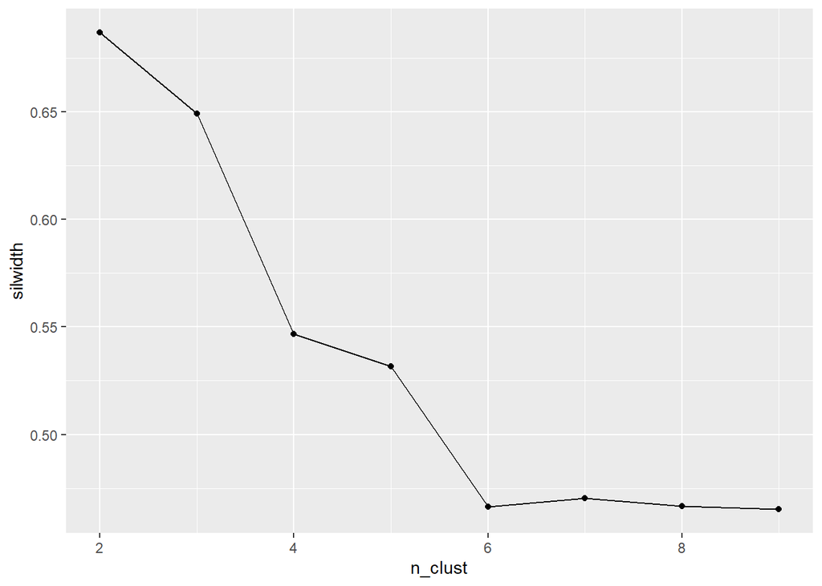

```r
## Make a plot
ggplot(sil_results, aes(n_clust,silwidth)) +
  geom_point() + geom_line()
```

# Drawbacks to silhouette scores

- Prefers compact shapes
- Doesn’t do well with complex shapes

# Exercise Cl.04

1. Analyze the silhouette scores for mtcars for cluster sizes of 2-19
2. Plot the results. Which cluster size would you pick?
3. Do you think your algorithm is performing well?

# Conclusion

- In this lecture you have learned how to implement both kmeans clustering and heirarchical clustering approaches with R.
- We also discussed different methods for assessing cluster performance, as well as methods for identifying the optimal number of clusters in a dataset.
- recall that clustering is inherently exploratory in nature - since we do not have labels, we cannot test how well we are doing.
- Also, recall there is no guarantee of getting meaningful results!
- However, this is still a situationally useful technique for exploring subspaces of datasets.